# Main_analysis

Jo Cutler & Sebastian Contreras-Huerta

03/08/2023

# Methods

## Set up and functions

## Load and organise the survey data

## Load and organise the effort data

## Load and organise the modelling data

## Means & correlations

## Mixed models of choices

## Mixed models of *K*s

## Mixed models of intervention effects on choices

## Mixed models of intervention effects on *K*s

## Mixed models of intervention effects on beta parameters

## Mixed models of intervention effects on WEPT

## Plot of sample

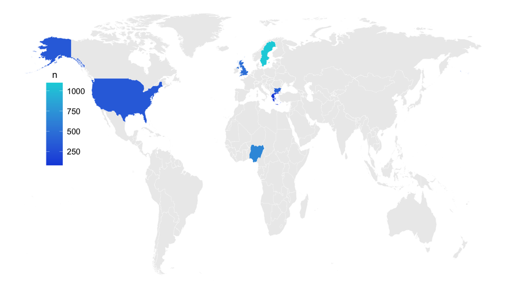

## Plots of choices

## Plots of *K* parameters

## Plots of beta parameters

## Plots of *K* parameters with other measures

## Plots of model identifiability, parameter recovery & model fit

# Results

## *Environmental benefits are devalued when they require effort*

### Figure 2:

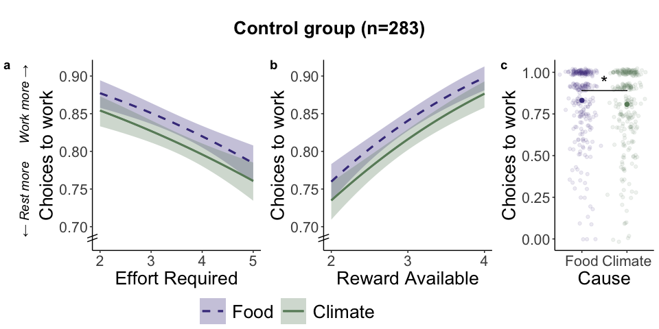

**Figure 2. Effort, reward, and cause determine choices to exert effort for the climate and food charities in the Pro-Environmental Effort Task (PEET) (a)** Participants in the control group (n=283), who did not experience a pro-environmental intervention, were more willing to choose to exert physical effort for rewards when the level of effort required was lower. **(b)** Willingness to work was also higher when the reward available was larger. **(c)** Control participants were more willing to choose work to help the food charity compared to the climate charity. Asterisks between food and climate represent a significant effect (p<0.05) of cause in the GLMM of choices.

## *Psychological interventions increase relative willingness to help the environment*

After establishing that rewards for the climate and the food charity were devalued by the effort required to obtain them, we directly compared choices to work between the two tightly matched charities in the control group. Strikingly, control participants showed a significant bias towards helping the food charity, over the climate charity (OR=1.13 [1.02, 1.25], *p*=0.017; Figure 2C). This bias further emphasises the importance of identifying interventions that can boost pro-environmental motivation.

Next, we examined how the 11 interventions, developed based on psychological theories specifically to facilitate pro-environmental actions and selected by experts, affected willingness to put in effort to help the climate relative to the food charity. We tested the impact of each intervention compared to the control group using a GLMM (see Methods). To establish results were robust, we also accounted for demographic characteristics that might affect motivation, differing times since starting the study, and motivation to engage in the study. Thus, we ran three control analyses: (i) age and gender, (ii) how much time had elapsed since participants started the study, and (iii) pages completed on the Work for Environmental Protection Task (WEPT; see Methods), an existing decision-making task always completed before the PEET.

Of 11 interventions, three increased choices to help the climate charity relative to the food charity with effects robust across control analyses: Psychological Distance (PD), System Justification (SJ) and Negative Emotions (NE; GLMM cause*intervention interactions control vs. PD OR=0.82 [0.71, 0.96], *p*=0.012; control vs. SJ OR=0.86 [0.74, 1.00], *p*=0.044; control vs. NE OR=0.85 [0.74, 0.99], *p*=0.036; Figure 3 & Figure S2).Participants who completed these interventions did not show the bias to help the food cause over the climate found in the control group, with Bayesian evidence of no difference between causes (Wilcoxon test PD V=6004, *p*=0.17, BF<sub>01</sub>=6.76; SJ V=9222, *p*=0.75, BF<sub>01</sub>=13.76; NE V=6762, *p*=0.79, BF<sub>01</sub>=12.00). A further intervention, Pluralistic Ignorance also significantly increased relative willingness to work for climate vs. food (OR=0.86 [0.74, 1.00], *p*=0.0498) but this was not robust to controlling for age & gender (OR=0.86 [0.74, 1.00], *p*=0.0503) or time in the study (OR=0.86 [0.74, 1.00], *p*=0.056; Table S4 for full results and see Supplementary Results & Table S5 for control analyses on WEPT performance in our sample).

### Figure 3

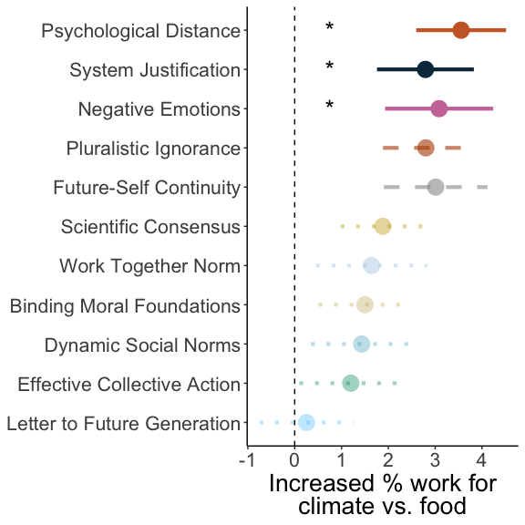

**Figure 3. Positive impact of interventions on willingness to exert effort to help the climate relative to the food charity.** Comparing choices for each intervention against the control group showed robust evidence that Psychological Distance, System Justification, and Negative Emotions interventions significantly increased relative willingness to work for the climate. There was also some evidence to support the effectiveness of the intervention based on Pluralistic Ignorance. Values plotted are the difference between each intervention and the control group (vertical line at zero) in choices to work for the climate – choices to work for the food charity. Significance was tested through cause (climate / food) by intervention (vs. control) interactions in GLMMs. Asterisks and solid lines show interventions with significant interaction effects that are robust across all three control models (for age and gender, time on the survey before the PEET, and pages completed in the WEPT). Dashed lines show interventions with a significant effect in the main model or at least one control model. Dotted lines are interventions that do not significantly interact with the cause (climate / food) in any model.

In summary, we identified several pro-environmental interventions that increased willingness to exert effort to help the climate, relative to willingness to help a non-climate cause. In particular, decreasing psychological distance between the participant and the changing environment, using system justification theory to promote pro-environmental action, and focusing on negative emotions about climate change increased relative willingness to help the environment.

## Changing pro-environmental motivation with psychological interventions

Again, these interventions completely eliminated the food over climate bias seen in the control group (Wilcoxon test PD V=15615, *p*=0.40, BF<sub>01</sub>=8.76; SJ V=19057, *p*=0.95, BF<sub>01</sub>=13.17; PI V=18543, *p*=0.74, BF<sub>01</sub>=14.80; FSC V=10608, *p*=0.52, BF<sub>01</sub>=12.91).

### Figure 4

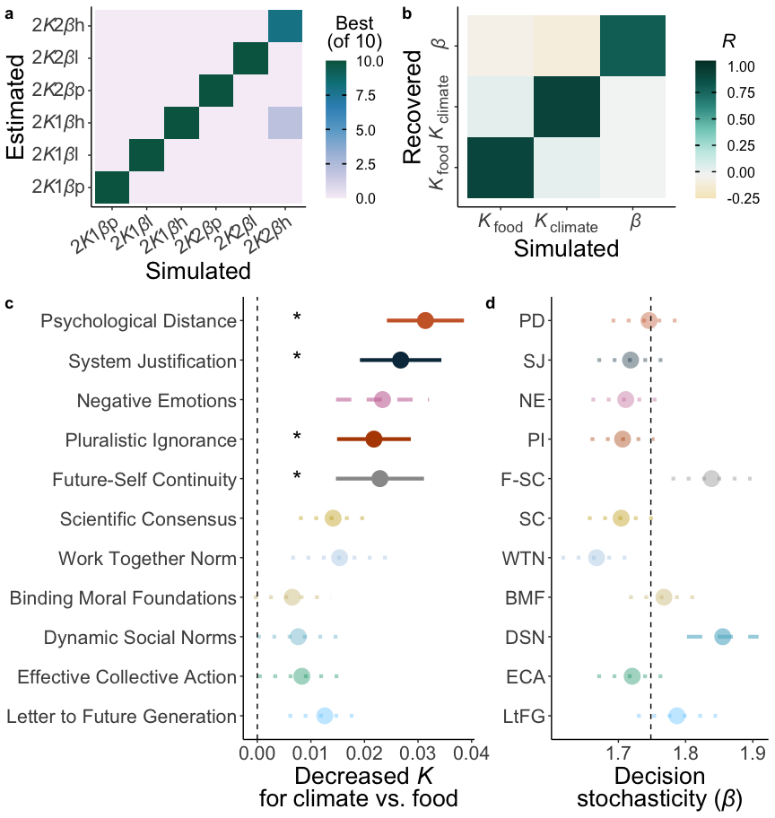

## *Motivation to take action for the climate is specifically associated with pro-environmental attitudes and beliefs*

An additional advantage of computational modelling is that the separate discounting K parameters precisely estimate motivation to exert effort to obtain rewards for each cause for each participant. This integrated measure can be used to examine how such motivation is related to individual difference in independent measures. In our final analyses, we combined data across interventions and tested whether motivation for effortful actions to help the environment (*Κ*<sub>climate</sub>) was associated with (i) climate-relevant measures of belief in human-made climate change and support for policies that protect the planet and (ii) general measures of trait apathy and current fatigue (see Methods). We also examined the same correlations for motivation to help the food charity (*Κ*<sub>food</sub>) to test the specificity of associations.

Motivation to exert effort for the climate was positively associated with belief in climate change (negative correlation with *Κ*s *r*<sub>(3055)</sub>=-0.20 [-0.23, -0.16], *p*<0.001) and support for pro-environmental policies (*r*<sub>(3037)</sub>=-0.19 [-0.22, -0.15] *p*<0.001). Importantly, these associations between climate-relevant measures and pro-environmental motivation were significantly stronger than the corresponding correlations with motivation to help the food cause (belief *r*<sub>(3055)</sub>=-0.09 [-0.12, -0.05], *p*<0.001; difference Z=4.33, *p*<0.001; Figure 5A; policy support *r*<sub>(3037)</sub>=-0.09 [-0.12, -0.05], *p*<0.001; difference Z=3.85, *p*<0.001; Figure 5B). In contrast, broader measures of trait apathy and how subjectively effortful participants found the highest effort level, showed significant negative associations for both climate motivation and food motivation, with no significant difference between causes (*Κ*<sub>climate</sub> & apathy *r*<sub>(2597)</sub>=0.10 [0.06, 0.14], *p*<0.001; *Κ*<sub>food</sub> & apathy *r*<sub>(2597)</sub>=0.09 [0.05, 0.13], *p*<0.001; difference Z=0.31, *p*=0.76; Figure 5C; *Κ*<sub>climate</sub> & subjective effort *r*<sub>(2969)</sub>=0.13 [0.09, 0.16], *p*<0.001; *Κ*<sub>food</sub> & apathy *r*<sub>(2969)</sub>=0.14 [0.11, 0.18], *p*<0.001; difference Z=0.55, *p*=0.58; Figure 5D). Finally, we examined associations between pages completed in the WEPT and motivation to help each cause. WEPT performance was positively correlated with motivation for both the climate (*r*<sub>(3055)</sub>=-0.16 [-0.20, -0.13], *p*<0.001 and food (*r*<sub>(3055)</sub>=-0.18 [-0.21, -0.14], *p*<0.001) charities, but importantly with no significant difference in the strength of these correlations (Z=0.54, *p*=0.59; Figure 5E). Together these results highlight the specificity of variability in motivation to help the climate driving individual differences in climate-relevant outcomes, but also that general motivation is an important factor in increasing willingness to exert effort for any cause.

### Figure 5

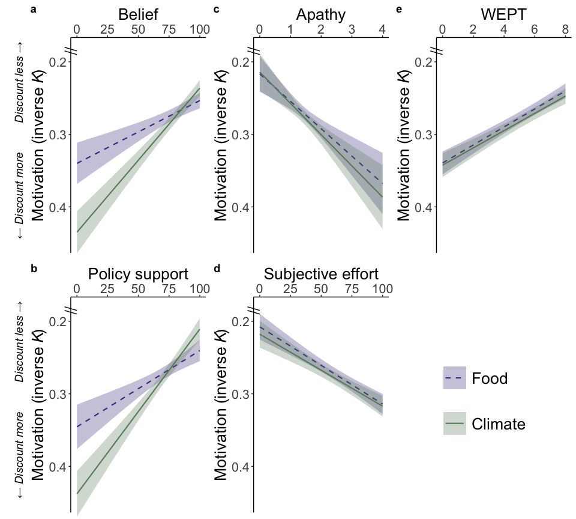

**Figure 5. Individual differences in pro-environmental motivation are specifically associated with climate beliefs and policy support.** Motivation to help the climate, captured in participants’ discounting *K* parameters, was associated with **(a)** beliefs that climate-change is humman-made (*r*<sub>(3055)</sub>=-0.20 [-0.23, -0.16], *p*<0.001) and **(b)** support for policies that protect the environment (*r*<sub>(3037)</sub>=-0.19 [-0.22, -0.15] *p*<0.001). These associations between pro-environmental motivation (*K*<sub>climate</sub>) and climate-relevant measures were significantly stronger than the corresponding association for motivation for the food charity (*K*<sub>food</sub>; belief difference Z=4.33, *p*<0.001; policy support difference Z=3.85, *p*<0.001). Considering measures of general motivation, both **(c)** trait apathy and **(d)** self-reported ratings of subjective effort were negatively associated with motivation for both the climate and food charity, with no significant differences between these correlations (*Κ*<sub>climate</sub> & apathy *r*<sub>(2597)</sub>=0.10 [0.06, 0.14], *p*<0.001; *Κ*<sub>food</sub> & apathy *r*<sub>(2597)</sub>=0.09 [0.05, 0.13], *p*<0.001; difference Z=0.31, *p*=0.76; *Κ*<sub>climate</sub> & subjective effort *r*<sub>(2969)</sub>=0.13 [0.09, 0.16], *p*<0.001; *Κ*<sub>food</sub> & apathy *r*<sub>(2969)</sub>=0.14 [0.11, 0.18], *p*<0.001; difference Z=0.55, *p*=0.58). **(e)** the number of pages completed on the Work for Environmental Protection Task (WEPT) also positively correlated with motivation (lower *K*) to help both causes (climate (*r*<sub>(3055)</sub>=-0.16 [-0.20, -0.13], *p*<0.001; food *r*<sub>(3055)</sub>=-0.18 [-0.21, -0.14], *p*<0.001) with no significant difference between these correlations (Z=0.54, *p*=0.59).

# Supplement

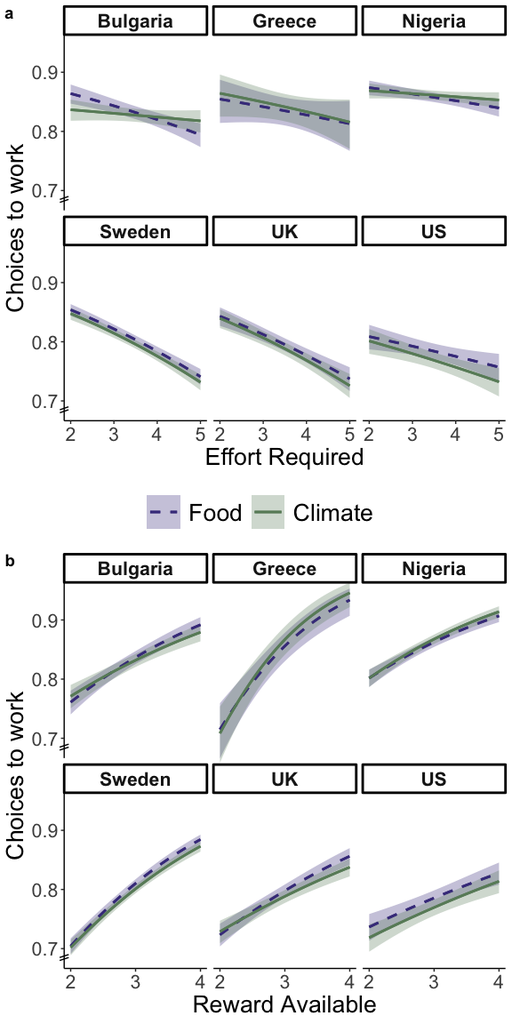

**Figure S1.**

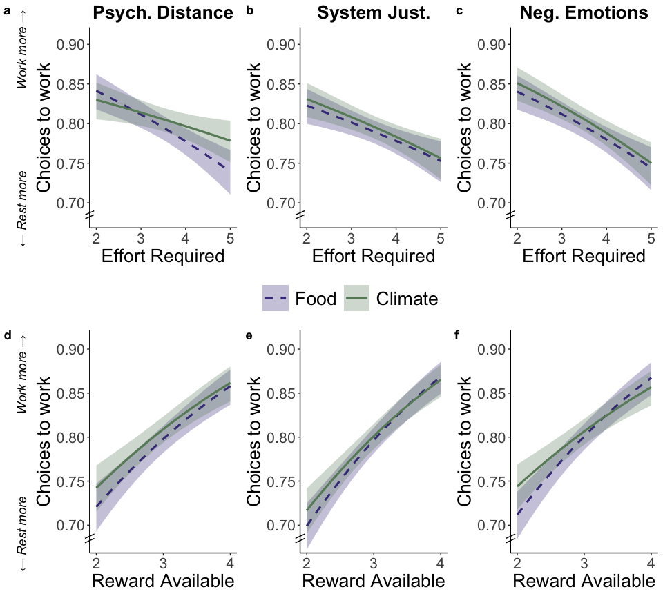

**Figure S2.**

**Table S2.**

GLMM of choices in control group

| Parameter | Coefficient | SE | CI_low | CI_high | z | p |
| --- | --- | --- | --- | --- | --- | --- |
| (Intercept) | 16.40 | 2.53 | 12.12 | 22.19 | 18.13 | <0.001 |
| Effort | 0.70 | 0.07 | 0.58 | 0.85 | -3.63 | <0.001 |
| Reward | 1.96 | 0.15 | 1.70 | 2.27 | 9.12 | <0.001 |
| Cause (Food > Climate) | 1.13 | 0.06 | 1.02 | 1.25 | 2.38 | 0.017 |

**Table S3.**

GLMM of choices in full sample

| Parameter | Coefficient | SE | CI_low | CI_high | z | p |
| --- | --- | --- | --- | --- | --- | --- |
| (Intercept) | 16.34 | 0.82 | 14.81 | 18.03 | 55.56 | <0.001 |
| Effort | 0.76 | 0.04 | 0.68 | 0.84 | -5.12 | <0.001 |
| Reward | 1.95 | 0.16 | 1.66 | 2.28 | 8.18 | <0.001 |
| Cause (Food > Climate) | 1.03 | 0.02 | 0.99 | 1.06 | 1.54 | 0.12 |

**Table S4.**

GLMM of choices in full sample - interventions

| Parameter | Coefficient | SE | CI_low | CI_high | z | p | agegen_p | t1_p | wept_p |
| --- | --- | --- | --- | --- | --- | --- | --- | --- | --- |
| (Intercept) | 17.73 | 2.63 | 13.26 | 23.71 | 19.39 | <0.001 | <0.001 | <0.001 | <0.001 |
| Effort | 0.76 | 0.04 | 0.68 | 0.84 | -5.12 | <0.001 | <0.001 | <0.001 | <0.001 |
| Reward | 1.95 | 0.16 | 1.66 | 2.28 | 8.17 | <0.001 | <0.001 | <0.001 | <0.001 |
| Cause (Food > Climate) | 1.13 | 0.06 | 1.02 | 1.26 | 2.36 | 0.018 | 0.018 | 0.022 | 0.018 |
| Work Together Norm | 0.76 | 0.16 | 0.50 | 1.16 | -1.26 | 0.21 | 0.24 | 0.25 | 0.27 |
| Negative Emotions | 0.74 | 0.16 | 0.49 | 1.13 | -1.40 | 0.16 | 0.14 | 0.19 | 0.11 |
| Scientific Consensus | 1.01 | 0.21 | 0.67 | 1.52 | 0.05 | 0.96 | 0.77 | 0.84 | 0.72 |
| Effective Collective Action | 0.81 | 0.17 | 0.54 | 1.23 | -0.98 | 0.33 | 0.36 | 0.33 | 0.13 |
| System Justification | 0.77 | 0.16 | 0.51 | 1.16 | -1.25 | 0.21 | 0.23 | 0.32 | 0.18 |
| Psychological Distance | 0.77 | 0.16 | 0.50 | 1.17 | -1.24 | 0.22 | 0.20 | 0.19 | 0.13 |
| Pluralistic Ignorance | 0.99 | 0.21 | 0.66 | 1.50 | -0.04 | 0.97 | 0.99 | 0.95 | 0.63 |
| Letter to Future Generation | 0.97 | 0.22 | 0.62 | 1.52 | -0.13 | 0.90 | 0.94 | 0.70 | 0.89 |
| Dynamic Social Norms | 1.28 | 0.27 | 0.84 | 1.94 | 1.16 | 0.25 | 0.26 | 0.22 | 0.47 |
| Future-Self Continuity | 1.22 | 0.28 | 0.78 | 1.91 | 0.88 | 0.38 | 0.42 | 0.38 | 0.58 |
| Binding Moral Foundations | 0.94 | 0.20 | 0.62 | 1.43 | -0.27 | 0.79 | 0.83 | 0.92 | 0.44 |
| Cause (Food > Climate) * Work Together Norm | 0.92 | 0.07 | 0.79 | 1.07 | -1.10 | 0.27 | 0.29 | 0.33 | 0.27 |
| Cause (Food > Climate) * Negative Emotions | 0.85 | 0.06 | 0.74 | 0.99 | -2.10 | 0.036 | 0.036 | 0.0493 | 0.036 |
| Cause (Food > Climate) * Scientific Consensus | 0.92 | 0.07 | 0.79 | 1.06 | -1.17 | 0.24 | 0.22 | 0.26 | 0.24 |
| Cause (Food > Climate) * Effective Collective Action | 0.93 | 0.07 | 0.80 | 1.07 | -1.02 | 0.31 | 0.32 | 0.36 | 0.31 |
| Cause (Food > Climate) * System Justification | 0.86 | 0.06 | 0.74 | 1.00 | -2.01 | 0.044 | 0.0498 | 0.0496 | 0.043 |
| Cause (Food > Climate) * Psychological Distance | 0.82 | 0.06 | 0.71 | 0.96 | -2.51 | 0.012 | 0.012 | 0.014 | 0.012 |
| Cause (Food > Climate) * Pluralistic Ignorance | 0.86 | 0.07 | 0.74 | 1.00 | -1.96 | 0.0498 | 0.0503 | 0.056 | 0.049 |
| Cause (Food > Climate) * Letter to Future Generation | 1.02 | 0.08 | 0.86 | 1.19 | 0.18 | 0.86 | 0.77 | 0.82 | 0.85 |
| Cause (Food > Climate) * Dynamic Social Norms | 0.93 | 0.07 | 0.80 | 1.08 | -0.95 | 0.34 | 0.35 | 0.39 | 0.34 |
| Cause (Food > Climate) * Future-Self Continuity | 0.85 | 0.07 | 0.72 | 1.00 | -1.92 | 0.055 | 0.054 | 0.048 | 0.054 |
| Cause (Food > Climate) * Binding Moral Foundations | 0.92 | 0.07 | 0.79 | 1.07 | -1.02 | 0.31 | 0.33 | 0.35 | 0.31 |

**Table S5.**

CLMM of WEPT in sample with and without PEET exclusions

| Parameter | Coefficient | SE | CI_low | CI_high | z | p | Coefficient_exc | SE_exc | CI_low_exc | CI_high_exc | z_exc | p_exc |
| --- | --- | --- | --- | --- | --- | --- | --- | --- | --- | --- | --- | --- |
| Work Together Norm | 0.78 | 0.06 | 0.67 | 0.90 | -3.44 | <0.001 | 0.92 | 0.13 | 0.70 | 1.22 | -0.57 | 0.57 |
| Negative Emotions | 0.79 | 0.06 | 0.68 | 0.91 | -3.21 | 0.001 | 1.24 | 0.18 | 0.94 | 1.64 | 1.51 | 0.13 |
| Scientific Consensus | 1.02 | 0.08 | 0.88 | 1.18 | 0.27 | 0.79 | 1.44 | 0.20 | 1.09 | 1.90 | 2.59 | 0.010 |
| Effective Collective Action | 0.87 | 0.06 | 0.75 | 1.01 | -1.85 | 0.064 | 1.51 | 0.22 | 1.14 | 2.00 | 2.90 | 0.004 |
| System Justification | 0.96 | 0.07 | 0.83 | 1.11 | -0.60 | 0.55 | 1.07 | 0.15 | 0.81 | 1.39 | 0.46 | 0.64 |
| Psychological Distance | 0.80 | 0.06 | 0.69 | 0.93 | -2.93 | 0.003 | 1.31 | 0.19 | 0.99 | 1.75 | 1.88 | 0.060 |
| Pluralistic Ignorance | 0.97 | 0.07 | 0.84 | 1.13 | -0.36 | 0.72 | 1.51 | 0.22 | 1.14 | 2.00 | 2.86 | 0.004 |
| Letter to Future Generation | 0.82 | 0.06 | 0.70 | 0.95 | -2.54 | 0.011 | 1.03 | 0.15 | 0.77 | 1.37 | 0.19 | 0.85 |
| Dynamic Social Norms | 1.09 | 0.08 | 0.94 | 1.26 | 1.16 | 0.25 | 1.41 | 0.20 | 1.07 | 1.87 | 2.44 | 0.015 |
| Future-Self Continuity | 0.92 | 0.07 | 0.79 | 1.08 | -1.00 | 0.32 | 1.32 | 0.20 | 0.98 | 1.77 | 1.80 | 0.072 |
| Binding Moral Foundations | 1.14 | 0.09 | 0.98 | 1.32 | 1.71 | 0.087 | 1.52 | 0.22 | 1.15 | 2.01 | 2.94 | 0.003 |

**Table S7.**

GLMM of choices in full sample - interventions, effort squared

| Parameter | Coefficient | SE | CI_low | CI_high | z | p | agegen_p | t1_p | wept_p |
| --- | --- | --- | --- | --- | --- | --- | --- | --- | --- |
| (Intercept) | 17.72 | 2.64 | 13.23 | 23.72 | 19.30 | <0.001 | <0.001 | <0.001 | <0.001 |
| Effort | 0.76 | 0.04 | 0.68 | 0.85 | -4.80 | <0.001 | <0.001 | <0.001 | <0.001 |
| Reward | 1.95 | 0.16 | 1.66 | 2.29 | 8.16 | <0.001 | <0.001 | <0.001 | <0.001 |
| Cause (Food > Climate) | 1.13 | 0.06 | 1.02 | 1.26 | 2.37 | 0.018 | 0.018 | 0.022 | 0.018 |
| Work Together Norm | 0.76 | 0.16 | 0.50 | 1.17 | -1.25 | 0.21 | 0.24 | 0.25 | 0.28 |
| Negative Emotions | 0.74 | 0.16 | 0.49 | 1.13 | -1.39 | 0.16 | 0.14 | 0.19 | 0.11 |
| Scientific Consensus | 1.01 | 0.21 | 0.67 | 1.53 | 0.05 | 0.96 | 0.77 | 0.84 | 0.72 |
| Effective Collective Action | 0.82 | 0.17 | 0.54 | 1.23 | -0.97 | 0.33 | 0.37 | 0.33 | 0.13 |
| System Justification | 0.77 | 0.16 | 0.51 | 1.16 | -1.25 | 0.21 | 0.24 | 0.31 | 0.18 |
| Psychological Distance | 0.77 | 0.17 | 0.50 | 1.17 | -1.24 | 0.22 | 0.20 | 0.19 | 0.14 |
| Pluralistic Ignorance | 0.99 | 0.21 | 0.66 | 1.50 | -0.03 | 0.97 | 1.00 | 0.95 | 0.63 |
| Letter to Future Generation | 0.97 | 0.22 | 0.62 | 1.52 | -0.13 | 0.90 | 0.94 | 0.70 | 0.89 |
| Dynamic Social Norms | 1.28 | 0.27 | 0.84 | 1.94 | 1.16 | 0.25 | 0.26 | 0.21 | 0.47 |
| Future-Self Continuity | 1.22 | 0.28 | 0.78 | 1.91 | 0.88 | 0.38 | 0.42 | 0.38 | 0.58 |
| Binding Moral Foundations | 0.94 | 0.20 | 0.62 | 1.43 | -0.27 | 0.79 | 0.83 | 0.92 | 0.44 |
| Cause (Food > Climate) * Work Together Norm | 0.92 | 0.07 | 0.79 | 1.07 | -1.10 | 0.27 | 0.29 | 0.33 | 0.27 |
| Cause (Food > Climate) * Negative Emotions | 0.85 | 0.06 | 0.74 | 0.99 | -2.10 | 0.036 | 0.036 | 0.0494 | 0.036 |
| Cause (Food > Climate) * Scientific Consensus | 0.92 | 0.07 | 0.79 | 1.06 | -1.17 | 0.24 | 0.22 | 0.26 | 0.24 |
| Cause (Food > Climate) * Effective Collective Action | 0.93 | 0.07 | 0.80 | 1.07 | -1.02 | 0.31 | 0.32 | 0.36 | 0.31 |
| Cause (Food > Climate) * System Justification | 0.86 | 0.06 | 0.74 | 1.00 | -2.02 | 0.044 | 0.0493 | 0.049 | 0.043 |
| Cause (Food > Climate) * Psychological Distance | 0.82 | 0.06 | 0.71 | 0.96 | -2.51 | 0.012 | 0.012 | 0.014 | 0.012 |
| Cause (Food > Climate) * Pluralistic Ignorance | 0.86 | 0.07 | 0.74 | 1.00 | -1.97 | 0.049 | 0.0495 | 0.055 | 0.048 |
| Cause (Food > Climate) * Letter to Future Generation | 1.02 | 0.08 | 0.86 | 1.19 | 0.18 | 0.86 | 0.78 | 0.82 | 0.85 |
| Cause (Food > Climate) * Dynamic Social Norms | 0.93 | 0.07 | 0.80 | 1.08 | -0.96 | 0.34 | 0.34 | 0.39 | 0.33 |
| Cause (Food > Climate) * Future-Self Continuity | 0.85 | 0.07 | 0.72 | 1.00 | -1.92 | 0.055 | 0.054 | 0.048 | 0.054 |
| Cause (Food > Climate) * Binding Moral Foundations | 0.92 | 0.07 | 0.79 | 1.08 | -1.02 | 0.31 | 0.34 | 0.35 | 0.31 |

**Table S8.**

GLMM of Ks in full sample - interventions

| Parameter | Coefficient | SE | CI_low | CI_high | t | df_error | p | agegen_p | t1_p | wept_p |
| --- | --- | --- | --- | --- | --- | --- | --- | --- | --- | --- |
| (Intercept) | 0.21 | 0.01 | 0.19 | 0.23 | -31.42 | 6082 | <0.001 | <0.001 | <0.001 | <0.001 |
| Cause (Food > Climate) | 0.97 | 0.02 | 0.94 | 1.01 | -1.51 | 6082 | 0.13 | 0.14 | 0.082 | 0.13 |
| Work Together Norm | 1.04 | 0.07 | 0.92 | 1.19 | 0.65 | 6082 | 0.51 | 0.54 | 0.57 | 0.62 |
| Negative Emotions | 1.05 | 0.07 | 0.92 | 1.20 | 0.78 | 6082 | 0.44 | 0.42 | 0.47 | 0.40 |
| Scientific Consensus | 0.99 | 0.06 | 0.87 | 1.12 | -0.18 | 6082 | 0.86 | 0.73 | 0.78 | 1.00 |
| Effective Collective Action | 1.04 | 0.07 | 0.92 | 1.19 | 0.66 | 6082 | 0.51 | 0.56 | 0.51 | 0.34 |
| System Justification | 1.05 | 0.07 | 0.93 | 1.20 | 0.78 | 6082 | 0.43 | 0.48 | 0.54 | 0.43 |
| Psychological Distance | 1.01 | 0.07 | 0.88 | 1.15 | 0.13 | 6082 | 0.90 | 0.87 | 0.88 | 0.80 |
| Pluralistic Ignorance | 0.97 | 0.06 | 0.85 | 1.10 | -0.55 | 6082 | 0.59 | 0.56 | 0.53 | 0.78 |
| Letter to Future Generation | 0.99 | 0.07 | 0.86 | 1.13 | -0.20 | 6082 | 0.84 | 0.78 | 0.90 | 0.81 |
| Dynamic Social Norms | 0.96 | 0.06 | 0.85 | 1.10 | -0.56 | 6082 | 0.57 | 0.58 | 0.55 | 0.73 |
| Future-Self Continuity | 0.97 | 0.07 | 0.85 | 1.12 | -0.37 | 6082 | 0.71 | 0.76 | 0.71 | 0.84 |
| Binding Moral Foundations | 0.99 | 0.07 | 0.87 | 1.13 | -0.15 | 6082 | 0.88 | 0.84 | 0.84 | 0.85 |
| Cause (Food > Climate) * Work Together Norm | 1.02 | 0.02 | 0.99 | 1.06 | 1.27 | 6082 | 0.20 | 0.18 | 0.26 | 0.20 |
| Cause (Food > Climate) * Negative Emotions | 1.04 | 0.02 | 1.00 | 1.07 | 1.95 | 6082 | 0.051 | 0.044 | 0.070 | 0.0502 |
| Cause (Food > Climate) * Scientific Consensus | 1.01 | 0.02 | 0.98 | 1.05 | 0.69 | 6082 | 0.49 | 0.46 | 0.54 | 0.49 |
| Cause (Food > Climate) * Effective Collective Action | 1.02 | 0.02 | 0.99 | 1.06 | 1.12 | 6082 | 0.26 | 0.25 | 0.31 | 0.27 |
| Cause (Food > Climate) * System Justification | 1.05 | 0.02 | 1.01 | 1.08 | 2.64 | 6082 | 0.008 | 0.012 | 0.010 | 0.008 |
| Cause (Food > Climate) * Psychological Distance | 1.06 | 0.02 | 1.03 | 1.10 | 3.42 | 6082 | <0.001 | <0.001 | <0.001 | <0.001 |
| Cause (Food > Climate) * Pluralistic Ignorance | 1.04 | 0.02 | 1.01 | 1.08 | 2.30 | 6082 | 0.022 | 0.021 | 0.027 | 0.021 |
| Cause (Food > Climate) * Letter to Future Generation | 1.01 | 0.02 | 0.97 | 1.05 | 0.50 | 6082 | 0.61 | 0.69 | 0.71 | 0.61 |
| Cause (Food > Climate) * Dynamic Social Norms | 1.02 | 0.02 | 0.99 | 1.06 | 1.38 | 6082 | 0.17 | 0.15 | 0.18 | 0.17 |
| Cause (Food > Climate) * Future-Self Continuity | 1.04 | 0.02 | 1.00 | 1.08 | 2.22 | 6082 | 0.027 | 0.021 | 0.025 | 0.027 |
| Cause (Food > Climate) * Binding Moral Foundations | 1.02 | 0.02 | 0.98 | 1.05 | 0.92 | 6082 | 0.36 | 0.39 | 0.41 | 0.36 |

**Table S9.**

GLMM of betas in full sample - interventions

| Parameter | Coefficient | SE | CI_low | CI_high | t | df_error | p | agegen_p | t1_p | wept_p |
| --- | --- | --- | --- | --- | --- | --- | --- | --- | --- | --- |
| (Intercept) | -0.01 | 0.06 | -0.13 | 0.11 | -0.17 | 6096 | 0.86 | 0.76 | 0.87 | 0.98 |
| Work Together Norm | -0.09 | 0.06 | -0.21 | 0.03 | -1.48 | 6096 | 0.14 | 0.23 | 0.16 | 0.22 |
| Negative Emotions | -0.04 | 0.06 | -0.16 | 0.08 | -0.64 | 6096 | 0.52 | 0.51 | 0.53 | 0.45 |
| Scientific Consensus | -0.06 | 0.06 | -0.17 | 0.06 | -0.94 | 6096 | 0.35 | 0.49 | 0.36 | 0.20 |
| Effective Collective Action | -0.04 | 0.06 | -0.15 | 0.08 | -0.62 | 6096 | 0.54 | 0.67 | 0.60 | 0.28 |
| System Justification | -0.03 | 0.06 | -0.14 | 0.09 | -0.47 | 6096 | 0.64 | 0.86 | 0.73 | 0.64 |
| Psychological Distance | 0.00 | 0.06 | -0.12 | 0.12 | -0.02 | 6096 | 0.98 | 0.88 | 0.76 | 0.82 |
| Pluralistic Ignorance | -0.05 | 0.06 | -0.16 | 0.07 | -0.78 | 6096 | 0.43 | 0.50 | 0.37 | 0.23 |
| Letter to Future Generation | 0.05 | 0.06 | -0.08 | 0.18 | 0.76 | 6096 | 0.45 | 0.32 | 0.43 | 0.43 |
| Dynamic Social Norms | 0.13 | 0.06 | 0.02 | 0.25 | 2.22 | 6096 | 0.026 | 0.030 | 0.023 | 0.062 |
| Future-Self Continuity | 0.12 | 0.06 | 0.00 | 0.25 | 1.91 | 6096 | 0.056 | 0.044 | 0.073 | 0.098 |
| Binding Moral Foundations | 0.02 | 0.06 | -0.10 | 0.14 | 0.33 | 6096 | 0.74 | 0.75 | 0.68 | 0.88 |

## Create source data